# Assignment 2.

**Information on how to navigate the notebook.**

All the assignments and questions are highlighted by putting them in quotes and italic, like this:

> *What is the Oxford English Dictionary's defintion of a narrative?*

While the answers and comments are written normally, like this text.

The notebook will require some time to run because of the model-fitting that has been performed. It is possible to just comment those cells.

```python
# Use the entire screen
from IPython.core.display import display, HTML
display(HTML("<style>.container { width:100% !important; }</style>"))
from IPython.core.display import Image, display
```

```python
import pprint
# plotting
%matplotlib inline
import matplotlib.pyplot as plt
import seaborn as sns
sns.set()

# math
import math
import random

# pandas and numpy
import numpy as np
import pandas as pd

# maps
import folium

# datetime
import datetime
from datetime import datetime

# machine learning
from sklearn import preprocessing
from sklearn.ensemble import RandomForestClassifier
from sklearn.model_selection import RandomizedSearchCV
from sklearn.model_selection import train_test_split
```

## Part 1: Questions to text and lectures.

> A) Please answer my questions to the Segal and Heer paper we read during lecture 7 and 8.

> *What is the Oxford English Dictionary's defintion of a narrative?*

**narrative** *noun*

1. [countable] a description of events, especially in a novel
2. [uncountable] the act, process or skill of telling a story

**narrative** *adjective* [only before noun]

- narrative fiction
- a narrative poem

*Reference:* [Oxford Learners Dictionary](https://www.oxfordlearnersdictionaries.com/definition/american_english/narrative)

Even though this is the online definition, it is worth noting that in the Segal and Heer paper we were assigned to read it is stated, and we quote: "*The Oxford English Dictionary defines narrative as an account of a series of events, facts, etc., given in order and with the establishing of connections between them.*"

> *What is your favorite visualization among the examples in section 3? Explain why in a few words.*

Our favorite visualization is the [Human Development Trends](https://www.gapminder.org/downloads/human-development-trends-2005/) described in section 3.4. It is easy to follow and navigate through. It tells a story clearly, concisely while demanding minimal effort from the viewer. It is worth mentioning our second favorite was "*Steroids or Not, the Pursuit is On*" it is meticulously put together comparing baseball players of different eras only limited by the narrating capacity of poster graphics.

> *What's the point of Figure 7?* *Use Figure 7 to find the most common design choice within each category for the Visual narrative and Narrative structure (the categories within visual narrative are 'visual structuring', 'highlighting', etc).*

The point of Figure 7 is to show categories of narrative visualizations.

**Visual Narrative**

These are visual devices that assist and facilitate the narrative, they are subdivided into :

1) *Visual structuring*, which are mechanisms that allow the user to keep track of his position within the entire whole.

2) *Highlighting*, which help direct the user's attention to a specific part of the visualization.

3) *Transition guidance* which is used to move from one aspect to another of the visualization without disorienting the user.

The most common design choices for each of the categories are the following:

| **CATEGORY** | Visual Structuring | Highlighting | Transiton Guidance |
| --- | --- | --- | --- |
| **MOST COMMON DESIGN** | Consistant Visual Platform | Feature Distinction | Animated Transistions |

**Narrative Structure**

These refer to non-visual mechanisms that help with telling the story, and are subdivided into:

1) *Ordering*, which refers to the way paths are organized. They could be no indication, allowing random access, there could be a linear path described by the author or it could be left to the user to decide which path to take.

2) *Interativity*, which refers to the ways the user can interact with the story.

3) *Messaging*, the ways comments and observations are presented to the user.

The most common design choices for each of the categories are the following:

| **CATEGORY** | Ordering | Interactivity | Messaging |
| --- | --- | --- | --- |
| **MOST COMMON DESIGN** | User Directed Path | Filtering/Selection/Search | Captions/Headlines |

> *Check out Figure 8 and section 4.3. What is your favorite genre of narrative visualization? Why? What is your least favorite genre? Why?*

Picking a favorite can be difficult as the choices are not mutally exclusive, to pick one we prefer *Slide Show* as a favourite. The main reason is because with an interactive slide-show one can effectively incorporate it with any of the other six other genres. All genres have their advantages over the others, depending on what type of data you are describing. An annotated graph is probably the easiest way to desribe a sports professional player's career statistics while a flowchart is advantageous when describing a standard operational procedure. However if you want to go into detail of every aspect of a players statistics or argue each and every reason behind every step of a flow chart, one would probably be better of with an interactive slide show which allows you to explore more details.

Our least favorite genre is video/animation, as it doesn't allow much interaction from the user or further exploration on aspects that one would want to dive deep into.

> B) Also please answer the questions to my talk on [explanatory data visualization](https://www.youtube.com/watch?v=yHKYMGwefso)

> *What are the three key elements to keep in mind when you design an explanatory visualization?*
1. Start with a question. Be clear what you want to communicate to the people.
2. Allow exploration (Overview first -> zoom and filter -> details on demand). Allow people to answer their own questions by exploring your visualization.
3. Know your audience and their capabilities. In essence. Be clear enough so that the audience can ask themselves questions and know how to get answers from your visualization.

> *In the video I talk about (1)* overview first*, (2)* zoom and filter*, (3)* details on demand*.
> - *Go online and find a visualization that follows these principles (don't use one from the video)*.

A good example of this is the interactive map that visualizes the spread of the coronavirus. Credit to Johns Hopkins University [Coronavirus COVID-19 global cases](https://gisanddata.maps.arcgis.com/apps/opsdashboard/index.html#/bda7594740fd40299423467b48e9ecf6)

> *Explain how it does achieves (1)-(3). It might be useful to use screenshots to illustrate your explanation.*

(1). It gives a good overview of the world map with red circular icons over each country. Size of the icons is proportional to the number of confirmed cases of COVID-19 in corresponding country.

(2). You can zoom in on the map and when you press the icon you get information in the top-left corner of how many confirmed cases there are for that country, how many have recovered and how many fatalities. In the bottom right corner you can select between 3 graphs which visualize the rate of which the virus is spreading in that country. First being a linear scale showing total number of confirmed cases each day for the past two months, second is the same information on a logarithmic scale and the third and last one is a histogram of number of new cases per day for the same time period as the others.

(3). On the left side of the screen is a list of countries in descending order by number of confirmed cases per country. When you select a country from the list you get more detailed information about the country. Furthermore, on the bottom right corner graphs you can hover over any of the points to see how many cases there were on that day.

[figure not shown]

(if the gif does not work, go here: https://github.com/St1Orri/sosugogn/blob/master/ezgif.com-video-to-gif.gif)

> *Explain in your own words: How is explanatory data analysis different from exploratory data analysis?*
> - `Exploratory` data analysis is when you explore the data. You have a general idea of how the data is gathered and what it aimed to describe even though you can not yet explain how the observed data represents the phenomena being measured or monitored. This involves e.g. outlier detection through visualisation and calculation of general statistics.
> - `Explanatory` data analysis aimes to explain the data. You have good knowledge of the data and you wish to present it to a given audience. You utilize visualisation methods and compute relevant statistics that you have found to be most descriptive to intuitively get your point accross.

## Part 2: Random Forest and Weather Data

### Part 2A: Random forest binary classification.

We start by preparing the dataset.

```python
df = pd.read_csv("data/Police_Department_Incident_Reports__Historical_2003_to_May_2018.csv")

df["Date"]=pd.to_datetime(df["Date"])
#Converting time to timedelta format
df.Time=pd.to_timedelta(df["Time"]+':00')
# for quick access and binning
df = df.assign(Year=df["Date"].dt.year)
df = df.assign(Month=df["Date"].dt.month)
df = df.assign(WeekDay=df["Date"].dt.dayofweek)
df = df.assign(Hour=df.Time.dt.components['hours'])
df = df.assign(Minute=df.Time.dt.components['minutes'])
df = df.assign(HourOfWeek=df["WeekDay"]*24+pd.to_numeric(df["Hour"]))
# to understand what they mean (uppercase the first letter to keep with the other column names)
df.rename(columns={"X":"Lon", "Y": "Lat"}, inplace = True)

# load the weather dataset for later
weather_data = pd.read_csv("data/weather_data.csv")
weather_data["date"] = pd.to_datetime(weather_data["date"]).dt.tz_localize(None)
weather_data.dropna(inplace=True)
```

Pick the categories, make a copy of dataset for later use, round the time (it is in 2 columns so we use a function to do so) and, finally, merge the police report and weather datasets

```python
cat_type1 = "BURGLARY"
cat_type2 = "FRAUD"
chosen_categories = [cat_type1, cat_type2]

df_cats = df[(df["Category"].isin(chosen_categories))][["Category", "PdDistrict", "HourOfWeek", "Date", "Time", "Month"]].copy()  # make a copy to allow faster access in the future

def round_date(date, time):
    return pd.to_datetime(datetime.strptime(date.strftime("%Y-%m-%d")+" "+"{:02d}".format(math.floor(time.seconds/3600)) + ":00", "%Y-%m-%d %H:%M"), utc = False)

df_cats["Rounded_datetime"] = df_cats[["Date","Time"]].apply(lambda dt: round_date(*dt), axis = 1)

df_cats_w_raw = pd.merge(df_cats,weather_data, how='inner', left_on="Rounded_datetime", right_on = "date")
```

Lets compare the original dataset's size with the new one, where we merged with the weather data.

```python
print("Number of incidents available in the police dataset: {}.".format(len(df_cats)))
print("Number of incidents available after merging with weather dataset: {}".format(len(df_cats_w_raw)))
print("Percentage reduction: {:.2f}%".format(100-100*len(df_cats_w_raw)/len(df_cats)))
```

```
Number of incidents available in the police dataset: 133085.
Number of incidents available after merging with weather dataset: 44760
Percentage reduction: 66.37%
```

Let us now look a little bit more into the merged dataset.

First, how many of each category do we have.

```python
df_cats_w_raw.groupby("Category").count()["PdDistrict"].to_dict()
```

```
{'BURGLARY': 30375, 'FRAUD': 14385}
```

From this result, we see that the dataset is imbalanced. Having an **imbalanced dataset** can lead to misleading results when evaluating the performance of our model. Most machine learning models operate using a *loss function* which is minimized. In the case of *binary classification* problems, the loss function is usually the *0-1 loss*, which, when used to measure error, it tells us the proportion of miss-classified observations. This, however, can be a *misleading measure* of how well our model is performing. In our case, for example, if our model were to always predict `BURGLARY`, it would misclassify $32\%$ of the time, which could be considered quite a good result, but the model would have not learned how to predict future crimes. Creating a balanced dataset is, therefore, particularly useful when we want to have our model learn how to predict even those observations that are more rare.

A **downside of balancing** a dataset is that we are *altering the distribution of the data*. Is what we are interested in is an unsupervised analysis of the data, which aims at describing the distribution of the data, we can see that altering it artificially would make it impossible.

The balancing needs to be performed by carefully picking random samples from the data available, as to not alter the overall behaviour of the data and introduce unwanted bias in the model.

```python
# undersample to minority class's size
N = sum(df_cats_w_raw.Category=="FRAUD")
# equal sample size
n_samples = N
data_clf = {}
# sample from each category
for cat in chosen_categories:
    data_clf[cat] = df_cats_w_raw[(df_cats_w_raw["Category"]==cat)].sample(n_samples, replace = True)

df_cats_w = pd.concat(data_clf.values())
```

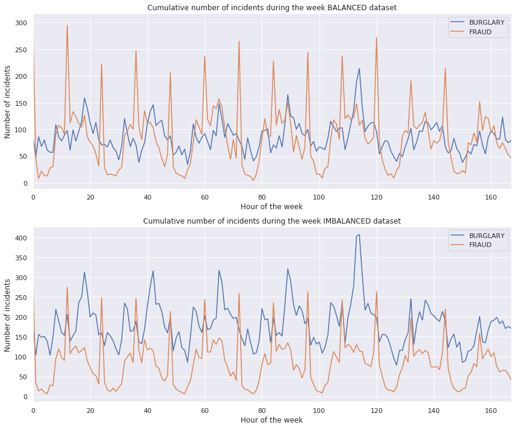

```python
fig, axes = plt.subplots(nrows = 2, ncols = 1, figsize = (12,10), tight_layout=True)

axes[0].set_title("Cumulative number of incidents during the week BALANCED dataset")
df_cats_w[df_cats_w["Category"] == chosen_categories[0]].groupby(["HourOfWeek"]).count()["PdDistrict"].plot(ax = axes[0], label = chosen_categories[0])
df_cats_w[df_cats_w["Category"] == chosen_categories[1]].groupby(["HourOfWeek"]).count()["PdDistrict"].plot(ax = axes[0], label = chosen_categories[1])
axes[0].set_xlabel("Hour of the week")
axes[0].set_ylabel("Number of incidents")
axes[0].legend()

axes[1].set_title("Cumulative number of incidents during the week IMBALANCED dataset")
df_cats_w_raw[df_cats_w_raw["Category"] == chosen_categories[0]].groupby(["HourOfWeek"]).count()["PdDistrict"].plot(ax = axes[1], label = chosen_categories[0])
df_cats_w_raw[df_cats_w_raw["Category"] == chosen_categories[1]].groupby(["HourOfWeek"]).count()["PdDistrict"].plot(ax = axes[1], label = chosen_categories[1])
axes[1].set_xlabel("Hour of the week")
axes[1].set_ylabel("Number of incidents")
axes[1].legend()

plt.show()
```

In the previous 2 graphs we compare the pattern of crimes dring the week. We can see that the overall pattern of the data is maintained. Therefore, we can see that our random sampling correctly keeps the overall behaviour but achieves the effect of having a balanced dataset.

We encode the data using the label encoder. We explore the results using one-hot encoding later.

```python
df_cats_w_labels = df_cats_w.copy() # make a copy to use for label encoding
# encode the target categories
le_cat = preprocessing.LabelEncoder()
df_cats_w_labels["Category"] = le_cat.fit_transform(df_cats_w_labels["Category"])

# encode the districts
le_districts = preprocessing.LabelEncoder()
df_cats_w_labels["PdDistrict"] = le_districts.fit_transform(df_cats_w_labels["PdDistrict"])

# encode the weather description
le_weather = preprocessing.LabelEncoder()
df_cats_w_labels["weather"] = le_weather.fit_transform(df_cats_w_labels["weather"])
```

Define a function to evaluate the performance of the classifier. And an additional function to plot importance of features.

```python
def performance_classifier(clf, dataset, classes, scaler = None):
    from sklearn.metrics import classification_report
    X = dataset.drop(columns="Category").to_numpy()
    if scaler is not None:
        X = scaler.transform(X)
    y_true = dataset["Category"].to_numpy()

    y_hat = clf.predict(X)

    print(classification_report(y_true, y_hat, target_names=classes))
def plot_importance(clf, features, figsize = (6,6)):
    sorted_idx = clf.feature_importances_.argsort()
    feature_names = np.array(features)
    y_ticks = np.arange(0, len(feature_names))
    fig, ax = plt.subplots(figsize = figsize)
    ax.barh(y_ticks,  clf.feature_importances_[sorted_idx])
    ax.set_yticklabels(feature_names[sorted_idx])
    ax.set_yticks(y_ticks)
    ax.set_title("Random Forest Feature Importances (MDI)")
    fig.tight_layout()
    plt.show()
```

Now we select a train and test split. The training data will be used in the cross validation.

```python
from sklearn.model_selection import train_test_split

train_p = 0.80

train_df_labels, test_df_labels = train_test_split(df_cats_w_labels, test_size=1-train_p, random_state = 42)
# make copies so they are not views of the original dataset
train_df_labels = train_df_labels.copy()
test_df_labels = test_df_labels.copy()
```

#### Baseline Random Forest with Labelled Dataset

Select the correct data.

```
              precision    recall  f1-score   support

    BURGLARY       0.70      0.67      0.68      2884
       FRAUD       0.68      0.71      0.70      2870

    accuracy                           0.69      5754
   macro avg       0.69      0.69      0.69      5754
weighted avg       0.69      0.69      0.69      5754
```

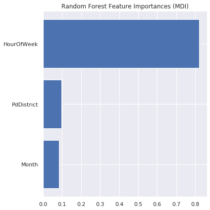

```python
features = ["PdDistrict","HourOfWeek", "Month"]
X = train_df_labels[features].to_numpy()
y = train_df_labels["Category"].to_numpy()

clf_label_b = RandomForestClassifier()
clf_label_b.fit(X,y)

performance_classifier(clf_label_b, test_df_labels[["Category"]+features], le_cat.classes_)

plot_importance(clf_label_b, features)
```

### Part 2B: Info from weather features

Selecting the correct features.

```
              precision    recall  f1-score   support

    BURGLARY       0.73      0.76      0.75      2884
       FRAUD       0.75      0.72      0.73      2870

    accuracy                           0.74      5754
   macro avg       0.74      0.74      0.74      5754
weighted avg       0.74      0.74      0.74      5754
```

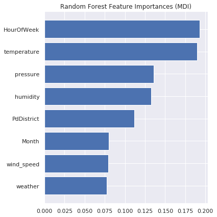

```python
features = ["PdDistrict", "HourOfWeek", "Month", "temperature", "humidity", "weather", "wind_speed", "pressure"]
X = train_df_labels[features].to_numpy()
y = train_df_labels["Category"].to_numpy()

clf_label_w = RandomForestClassifier()
clf_label_w.fit(X,y)

performance_classifier(clf_label_w, test_df_labels[["Category"]+features], le_cat.classes_)

plot_importance(clf_label_w, features)
```

#### Using one-hot encoding to get more interpretability

We look into one-hot encoding the categorical data.

```python
df_cats_w_onehot = df_cats_w.copy() # make a copy to use for encoding

# encode the target categories
le_cat = preprocessing.LabelEncoder()
df_cats_w_onehot["Category"] = le_cat.fit_transform(df_cats_w_onehot["Category"])

# one-hot encode the entire dataset
df_cats_w_onehot = pd.get_dummies(df_cats_w_onehot)

train_p = 0.80

train_df_onehot, test_df_onehot = train_test_split(df_cats_w_onehot, test_size=1-train_p, random_state = 42)
# make copies so they are not views of the original dataset
train_df_onehot = train_df_onehot.copy()
test_df_onehot = test_df_onehot.copy()
```

```
              precision    recall  f1-score   support

    BURGLARY       0.71      0.66      0.69      2884
       FRAUD       0.68      0.73      0.71      2870

    accuracy                           0.70      5754
   macro avg       0.70      0.70      0.70      5754
weighted avg       0.70      0.70      0.70      5754
```

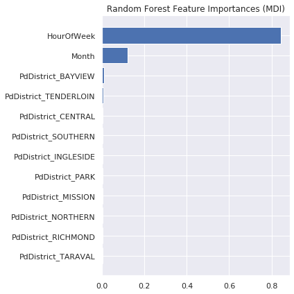

```python
features = ["HourOfWeek", "Month"]
for col in df_cats_w_onehot.columns:
    if col.split("_")[0] == "PdDistrict":
        features.append(col)

# create the training dataset
X = train_df_onehot[features].to_numpy()
y = train_df_onehot["Category"].to_numpy()

clf_onehot_b = RandomForestClassifier(n_estimators = 100)
clf_onehot_b.fit(X,y)

performance_classifier(clf_onehot_b, test_df_onehot[["Category"]+features], le_cat.classes_)

plot_importance(clf_onehot_b, features)
```

```
              precision    recall  f1-score   support

    BURGLARY       0.74      0.78      0.76      2884
       FRAUD       0.76      0.73      0.75      2870

    accuracy                           0.75      5754
   macro avg       0.75      0.75      0.75      5754
weighted avg       0.75      0.75      0.75      5754
```

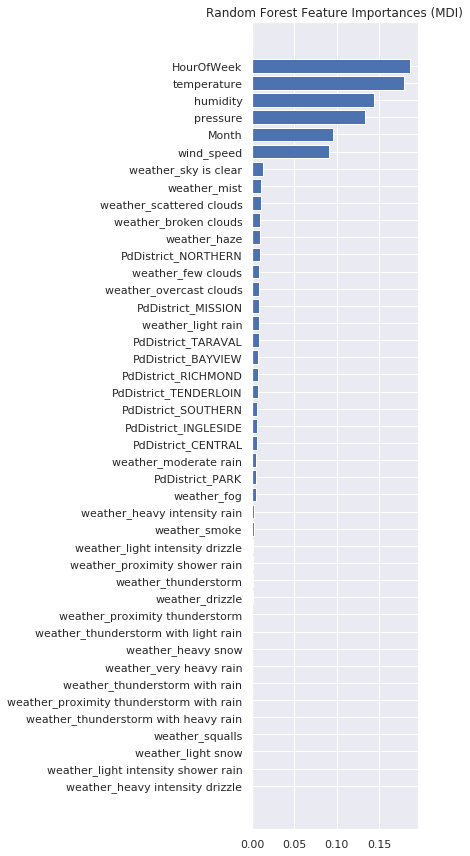

```python
features = ["HourOfWeek", "Month", "temperature", "humidity", "wind_speed", "pressure"]
for col in df_cats_w_onehot.columns:
    if (col.split("_")[0] == "PdDistrict") or (col.split("_")[0] == "weather"):
        features.append(col)

# create the training dataset
X = train_df_onehot[features].to_numpy()
y = train_df_onehot["Category"].to_numpy()

clf_onehot_w = RandomForestClassifier()
clf_onehot_w.fit(X,y)

performance_classifier(clf_onehot_w, test_df_onehot[["Category"]+features], le_cat.classes_)

plot_importance(clf_onehot_w, features, (6,12))
```

We see that the performance is no different between using a label encoding or a one-hot encoding. This is due to the nature of the problem. Even when a order to the events is given, each of the trees in the random forest classifier is capable of selecting the correct intervals, irrespective of whether an orthogonal encoding has been provided. However, we get more interpretable results from the one-hot encoding.

**Comment on the results**

Thanks to the feature importance graphs we can also see that the hour of the week and the temperature are the most important features in determining the category of a crime, followed by humidity, pressure and month of the year. Among the weather classes, we see that to most important one is whether the sky is clear, which makes sense for a crime like burglary.

We picked features based on the feature importance graph on models which used more complex features and on assumptions on the nature of the crime. We expected that the hour of the week would not be enough to predict crimes, as we saw in previous week that a monthly pattern is also present, i.e. incident numbers were different between summer months and winter months. Additionally, we removed wind-direction as we deemed it not influencing the crime rate.

We now explore some hyperparameter tuning to see if we can increase the performance of the model without overfitting.

```python
n_estimators = [int(x) for x in np.linspace(start = 10, stop = 250, num = 5)] # Number of trees in random forest
max_features = ['auto', 'sqrt'] # Number of features to consider at every split
max_depth = [int(x) for x in np.linspace(10, 20, num = 5)] # Maximum number of levels in tree
max_depth.append(None)
min_samples_split = [2, 5, 7, 10, 20] # Minimum number of samples required to split a node
min_samples_leaf = [1, 2, 4] # Minimum number of samples required at each leaf node
random_grid = {'n_estimators': n_estimators,
               'max_features': max_features,
               'max_depth': max_depth,
               'min_samples_split': min_samples_split,
               'min_samples_leaf': min_samples_leaf}
```

```
Fitting 10 folds for each of 50 candidates, totalling 500 fits
```

```
[Parallel(n_jobs=10)]: Using backend LokyBackend with 10 concurrent workers.
[Parallel(n_jobs=10)]: Done  21 tasks      | elapsed:   20.4s
[Parallel(n_jobs=10)]: Done 142 tasks      | elapsed:  2.0min
[Parallel(n_jobs=10)]: Done 345 tasks      | elapsed:  4.4min
[Parallel(n_jobs=10)]: Done 500 out of 500 | elapsed:  6.7min finished
```

```
              precision    recall  f1-score   support

    BURGLARY       0.72      0.66      0.69      2884
       FRAUD       0.68      0.74      0.71      2870

    accuracy                           0.70      5754
   macro avg       0.70      0.70      0.70      5754
weighted avg       0.70      0.70      0.70      5754
```

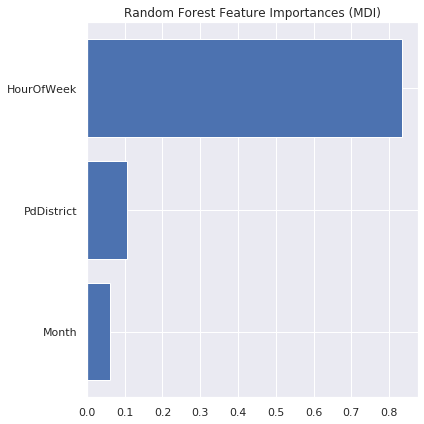

```python
features = ["PdDistrict","HourOfWeek", "Month"]
X = train_df_labels[features].to_numpy()
y = train_df_labels["Category"].to_numpy()


rf = RandomForestClassifier()
rf_random = RandomizedSearchCV(estimator = rf, param_distributions = random_grid,
                               n_iter = 50, cv = 10, verbose=2,
                               random_state=42, n_jobs = 10, refit=True)
# Fit the random search model
rf_random.fit(X, y)
best_clf = rf_random.best_estimator_

performance_classifier(best_clf, test_df_labels[["Category"]+features], le_cat.classes_)

plot_importance(best_clf, features)
```

```python
performance_classifier(best_clf, train_df_labels[["Category"]+features], le_cat.classes_)
```

```
              precision    recall  f1-score   support

    BURGLARY       0.88      0.85      0.87     11501
       FRAUD       0.85      0.89      0.87     11515

    accuracy                           0.87     23016
   macro avg       0.87      0.87      0.87     23016
weighted avg       0.87      0.87      0.87     23016
```

```python
features = ["PdDistrict", "HourOfWeek", "Month", "temperature", "humidity", "weather", "wind_speed", "pressure"]
X = train_df_labels[features].to_numpy()
y = train_df_labels["Category"].to_numpy()

rf_w = RandomForestClassifier()
rf_random_w = RandomizedSearchCV(estimator = rf_w, param_distributions = random_grid,
                               n_iter = 50, cv = 10, verbose=2,
                               random_state=42, n_jobs = 10, refit=True)
# Fit the random search model
rf_random_w.fit(X, y)
best_clf = rf_random_w.best_estimator_

performance_classifier(best_clf, test_df_labels[["Category"]+features], le_cat.classes_)
```

```
Fitting 10 folds for each of 50 candidates, totalling 500 fits
```

```
[Parallel(n_jobs=10)]: Using backend LokyBackend with 10 concurrent workers.
[Parallel(n_jobs=10)]: Done  21 tasks      | elapsed:   22.9s
[Parallel(n_jobs=10)]: Done 142 tasks      | elapsed:  2.5min
[Parallel(n_jobs=10)]: Done 345 tasks      | elapsed:  6.0min
[Parallel(n_jobs=10)]: Done 500 out of 500 | elapsed:  9.3min finished
```

```
              precision    recall  f1-score   support

    BURGLARY       0.76      0.75      0.76      2884
       FRAUD       0.75      0.77      0.76      2870

    accuracy                           0.76      5754
   macro avg       0.76      0.76      0.76      5754
weighted avg       0.76      0.76      0.76      5754
```

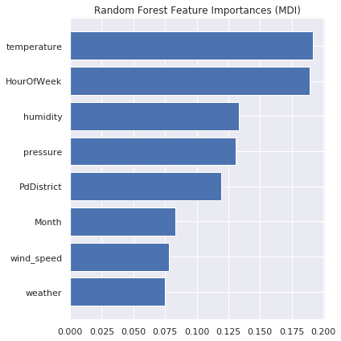

```python
plot_importance(best_clf, features, (6,6))
```

```python
performance_classifier(best_clf, train_df_labels[["Category"]+features], le_cat.classes_)
```

```
              precision    recall  f1-score   support

    BURGLARY       0.99      0.99      0.99     11501
       FRAUD       0.99      0.99      0.99     11515

    accuracy                           0.99     23016
   macro avg       0.99      0.99      0.99     23016
weighted avg       0.99      0.99      0.99     23016
```

This model appears to be overfitting, but we used Cross Validation to make sure that the parameters chosen would achieve the best validation error possible, and the validation error is a better estimate of the true generalization error of the model. So we look into it by testing a more complex model, to see if what was found is actually overfitting.

```python
features = ["PdDistrict", "HourOfWeek", "Month", "temperature", "humidity", "weather", "wind_speed", "pressure"]
X = train_df_labels[features].to_numpy()
y = train_df_labels["Category"].to_numpy()

rf_w = RandomForestClassifier(max_depth = None)
rf_w.fit(X, y)
```

```
RandomForestClassifier(bootstrap=True, class_weight=None, criterion='gini',
                       max_depth=None, max_features='auto', max_leaf_nodes=None,
                       min_impurity_decrease=0.0, min_impurity_split=None,
                       min_samples_leaf=1, min_samples_split=2,
                       min_weight_fraction_leaf=0.0, n_estimators=10,
                       n_jobs=None, oob_score=False, random_state=None,
                       verbose=0, warm_start=False)
```

```python
performance_classifier(rf_w, test_df_labels[["Category"]+features], le_cat.classes_)
```

```
              precision    recall  f1-score   support

    BURGLARY       0.75      0.77      0.76      2884
       FRAUD       0.76      0.74      0.75      2870

    accuracy                           0.75      5754
   macro avg       0.75      0.75      0.75      5754
weighted avg       0.75      0.75      0.75      5754
```

```python
performance_classifier(rf_w, train_df_labels[["Category"]+features], le_cat.classes_)
```

```
              precision    recall  f1-score   support

    BURGLARY       0.98      0.98      0.98     11501
       FRAUD       0.98      0.98      0.98     11515

    accuracy                           0.98     23016
   macro avg       0.98      0.98      0.98     23016
weighted avg       0.98      0.98      0.98     23016
```

We can see that with hyperparameter tuning the performance did not increase much, this is likely attributable to the fact that increase the complexity of the model is leading to overfitting. Therefore, the final model, after tuning, is not much different from the original one.

The overfitting of the model could be due to the model not being powerful enough to handle the data available or to the fact that not enough information was available.

**Final comments on classification**

Something interesting we learned from this is that the district is not very influential in determining what crime will be committed. However, hour of the week and temperature are extremely powerful indicators of which crime might happen.

## Part 3: Data visualization

> - *Create the Bokeh visualization from Part 2 of the Week 8 Lecture, displayed in a beautiful `.gif` below.*
> - *Provide nice comments for your code. Don't just use the `# inline comments`, but the full Notebook markdown capabilities and explain what you're doing.*

[figure not shown]

### Loading packages and setting up the data

First the necessary packages is loaded. `bokeh.plotting` is used for the figures and plotting related tools, such as `vbar` and `figure` functions. `bokeh.models` is used for more low level objects, such as `ColumnDataSource` to convert a data frame to a Bokeh dataframe, `FactorRange`, which defines the range of the factors, in this case it will be `Hour` and legends. Finally, the last class to use is `bokeh.palettes`, this is simply to get the color palettes for each of the created plots. `output_notebook` will make sure the output can be seen in Jupyter notebooks. The `bokeh.transform` transforms the plot. Here the function `dodge` will create an offset on the x-axis, notice in the GIF a wrong offset is seen, the bar for 1 is not below one. This is fixed using visual dodging.

```python
from bokeh.plotting import *
from bokeh.models import ColumnDataSource, FactorRange, Legend
from bokeh.palettes import Category20
from bokeh.transform import dodge
output_notebook()
focuscrimes = set(['WEAPON LAWS', 'PROSTITUTION', 'DRIVING UNDER THE INFLUENCE', 'ROBBERY', 'BURGLARY', 'ASSAULT', 'DRUNKENNESS', 'DRUG/NARCOTIC', 'TRESPASS', 'LARCENY/THEFT', 'VANDALISM', 'VEHICLE THEFT', 'STOLEN PROPERTY', 'DISORDERLY CONDUCT'])

# select the data we need for this visualization
df = df[(df.Year >= 2010)&(df.Year <= 2018)]
```

Now the data is set up. First the data from 2010 to 2018 is grouped by hours for each of the categories containing the crime types.

```python
hourly_crimes_by_category=df.groupby(["Category","Hour"]).count()["IncidntNum"]
```

As crimes vary a lot in numbers, the distribution of each of the crimes is found. By looking at the relative frequency, of each crime, it is now possible to compare the individual crimes with each other, as large counts will be in the same range as small counts. This is done by normalisation for within crime category $z_i$, which is given by: $$z_{i,h}=\frac{n_{i,h}}{\sum_h n_{i,h}}$$ Where $i$ indicates the specific crime category and $h$ is the hour, $n$ is the count. Finally the normalised data frame is organised into a column format. This enables a full control of how the data is flattened, as `ColumnDataSource` is a mapping between column names and lists of data. This means multiindexed data frames will be flattened.

```python
total_crimes_by_category = df.groupby("Category")["IncidntNum"].count()
zih=(hourly_crimes_by_category/total_crimes_by_category).unstack(0)
zih.head(2)
```

| Category Hour | ARSON | ASSAULT | BAD CHECKS | BRIBERY | BURGLARY | DISORDERLY CONDUCT | DRIVING UNDER THE INFLUENCE | DRUG/NARCOTIC | DRUNKENNESS | EMBEZZLEMENT | ... | SEX OFFENSES, NON FORCIBLE | STOLEN PROPERTY | SUICIDE | SUSPICIOUS OCC | TREA | TRESPASS | VANDALISM | VEHICLE THEFT | WARRANTS | WEAPON LAWS |
| --- | --- | --- | --- | --- | --- | --- | --- | --- | --- | --- | --- | --- | --- | --- | --- | --- | --- | --- | --- | --- | --- |
| 0 | 0.067711 | 0.056020 | 0.150160 | 0.055662 | 0.040369 | 0.051810 | 0.120817 | 0.034649 | 0.080556 | 0.190544 | ... | 0.172840 | 0.043381 | 0.042320 | 0.063621 | NaN | 0.028360 | 0.054232 | 0.036007 | 0.039722 | 0.052619 |
| 1 | 0.062183 | 0.047603 | 0.003195 | 0.032630 | 0.027909 | 0.038077 | 0.111638 | 0.020519 | 0.077183 | 0.003582 | ... | 0.012346 | 0.033159 | 0.028213 | 0.030324 | NaN | 0.020438 | 0.037981 | 0.024197 | 0.026858 | 0.037852 |

2 rows × 39 columns

The data frame is now converted to a Bokeh data frame

```python
df_bokeh = ColumnDataSource(zih)
```

### Initializing the figure

Next the figure is initialized, defining the base plot for the glyphs. Here height and width of the plot can be specified. The x-axis range given by the `FactorRange` function, this is simply the hours, in this case. Another neat feature, is the toolbar, here tools can be added, such as wheel zooming, box zooming, panning and so on. Finally title and labels are added to the figure and the y-axis is moved to 0 as negative values are impossible.

```python
hours=[str(i) for i in (zih.index.values+1)]

p = figure(plot_width=1200, plot_height=600, x_range = FactorRange(factors=hours),
          toolbar_location="above", tools="pan,wheel_zoom,box_zoom,reset")
p.title.text = "Crimes Per Hour"
p.title.text_font_size = "15px"
p.xaxis.axis_label = 'Hour of the day'
p.yaxis.axis_label = 'Relative frequency'
p.y_range.start = 0
```

### Adding glyphs

Now the glyphs are added to the figure. A glyph for each category of crime is needed, therefore a loop will be used to loop through each category and also to use the bokeh palette `Category20` to define the color of each category. A custom made legend is also used, to move it outside of the plot axis, by specifying the category and the glyph render in a tuple, store in `items`. The legend in bokeh can be interactive and have specified click policy. The `muted` object defines if the objects in the figure should be rendered as muted or not. The `muted_alpha` object specifies how much the bars should be muted before clicking on them (set by the click policy). The `dodge` function fixes the offset by moving the x-axis by adding 0.5 to the range of x.

```python
bar={}
items = []

for indx, (i, color) in enumerate(zip(focuscrimes, Category20[14])):
    bar[i] = p.vbar(x=dodge('Hour',  0.5, range=p.x_range),  top=i, source=df_bokeh, width=0.8, alpha=0.8, color=color,
                      muted_alpha=0.03, muted = True)
    items.append((i, [bar[i]]))
```

The legend is specified and given a location and also a click policy. The click policy is set to muted, this means that when clicking the legend, the corresponding glyph will be muted. Another click policy could be `hide`, this will hide the glyph when clicking on the category in the legend. Using `show` the final plot can be observed below. (If nothing is displayed we made a small video or run again the first 3 cells of this notebook and all the cells in the part 3 section).

```python
legend = Legend(items=items, location=(0, 180), click_policy="mute")
p.add_layout(legend, "left")
show(p)
```

[interactive chart not shown]

It is easy to compare crimes per hour now. Simply click the legend to mute or unmute. The toolbar in the right corner can also be used to zoom or panning. As an example, comparing the relative frequency of `DRIVING UNDER THE INFLUENCE` and `DRUG/NARCOTIC`. It is seen that `DRIVING UNDER THE INFLUENCE` occur mainly during the late evening/night 22:00-03:00, while `DRUG/NARCOTIC` mainly occur during the day hours, especially after work hours 16:00-19:00.

```python
from IPython.display import YouTubeVideo
YouTubeVideo("L-mWHGVo_kU",width=800, height=450)
```

[video not shown]